# Applr Test Suite

2026-08-10 16:27

This report does **not** execute any case itself. It invokes `Rscript tests/run.R` once — the exact command the terminal / a coding agent runs — and then displays the artifacts of that run: the PNGs and captured console output in `tests/output/`, plus each case’s status straight from the runner. What you see here is, by construction, what `run.R` produced. Knit from the package root with:

```
Rscript -e "rmarkdown::render('tests/report.Rmd')"
```

To keep a progress snapshot, rename the resulting `report.html` (e.g. `report 2026-07-06.html`) and move it into `tests/archive/`.

# Snapshot

**176 / 176 cases OK.**

All cases passing.

**Full runner transcript (exactly what the terminal shows)**

```
Running 176 case(s)...

  ap_01_single_predictor                 [visual] OK
  ap_02_additive_imputed                 [visual] OK
  ap_03_ytransform_log                   [visual] OK
  ap_04_transformed_predictor            [visual] OK
  ap_05_factor_colored                   [visual] OK
  ap_06_err_non_lm                       [console] OK
  ap_07_err_no_data_argument             [console] OK
  ap_08_local_data                       [console] OK
  ap_09_factor_first_predictor           [console] OK
  ap_10_err_dollar_names                 [console] OK
  ap_11_passthrough_args                 [visual] OK
  ap_12_mapping                          [visual] OK
  ap_13_summary_console                  [visual] OK
  ap_14_mapping_nonmodel_var             [visual] OK
  ap_15_auto_color_facet                 [visual] OK
  as_01_single_predictor                 [visual] OK
  as_02_additive_default                 [visual] OK
  as_03_multiplicative                   [visual] OK
  as_04_multiplicative_x_axis_x          [visual] OK
  as_05_interaction_three_slices         [visual] OK
  as_06_quadratic                        [visual] OK
  as_07_ytransform_inverse               [visual] OK
  as_08_ytransform_sqrt                  [visual] OK
  as_09_ytransform_log                   [visual] OK
  as_10_ytransform_exp                   [visual] OK
  as_11_ytransform_square                [visual] OK
  as_12_err_non_lm                       [console] OK
  as_13_err_nonexistent_x_axis           [console] OK
  as_14_err_factor_x_axis                [console] OK
  as_15_err_dollar_names                 [console] OK
  as_16_err_character_variable           [console] OK
  as_17_err_no_plot_open                 [console] OK
  as_18_err_wrong_data_plot              [console] OK
  as_19_err_mismatched_x_axis            [console] OK
  as_20_err_transformed_y_plot           [console] OK
  as_21_err_back_transform_invalid       [console] OK
  as_22_err_back_transform_extra_args    [console] OK
  as_23_interval_confidence              [visual] OK
```

[output cut: 127 more lines]

```
  sb_10_warn_no_slice_layer              [console] OK
  sb_11_warn_multiple_models             [console] OK
  sb_12_band_spanning                    [visual] OK
  sb_13_band_and_held                    [visual] OK
  sb_14_long_equation_wraps              [visual] OK
  sb_15_narrow_plot_wraps                [visual] OK
  sb_16_ambiguous_levels_no_fallback     [visual] OK
  sb_17_style_pinned                     [visual] OK
  sb_18_warn_bad_style                   [console] OK
  sb_19_brackets_keeps_indent            [visual] OK
  sb_20_indent_lost_names_return         [visual] OK

176/176 OK

Visual outputs are in tests/output/ — compare each against tests/reference/<id>.png
```

Note: an `OK` on a visual case means it ran, produced a plot, and its console output matched its snapshot (or was silent) — visual correctness is still judged by eye against the reference images below.

# Overview

## Show

```r
case_files <- sort(list.files("tests/cases", pattern = "\\.R$", full.names = TRUE))
meta <- lapply(case_files, parse_case_header)
overview <- data.frame(
  Case     = vapply(meta, `[[`, "", "id"),
  Status   = status$status[match(vapply(meta, `[[`, "", "id"), status$id)],
  Type     = vapply(meta, `[[`, "", "type"),
  Function = vapply(meta, `[[`, "", "func"),
  Expect   = vapply(meta, function(m) {
    e <- ifelse(is.na(m$expect), "", m$expect)
    if (nchar(e) > 110) paste0(substr(e, 1, 110), "...") else e
  }, "")
)
knitr::kable(overview, row.names = FALSE)
```

| Case | Status | Type | Function | Expect |
| --- | --- | --- | --- | --- |
| ap_01_single_predictor | OK | visual | autoplot | Complete plot built by autoplot(model) alone: mtcars scatter (disp on x, mpg on y), one straight downward-slop… |
| ap_02_additive_imputed | OK | visual | autoplot | autoplot picks the model’s FIRST predictor (disp) for the x-axis. mtcars scatter (disp vs mpg) with one straig… |
| ap_03_ytransform_log | OK | visual | autoplot | autoplot’s all.vars() strips the response transform, so the y-axis is RAW mpg even though the model is log(mpg… |
| ap_04_transformed_predictor | OK | visual | autoplot | autoplot’s all.vars() strips the predictor transform, so the x-axis is RAW disp even though the model is mpg ~… |
| ap_05_factor_colored | OK | visual | autoplot | iris scatter (Petal.Length vs Sepal.Length). Species is a non-numeric second predictor, so autoplot shows it a… |
| ap_06_err_non_lm | OK | console | autoplot | A clear error rejecting the non-lm object. A data.frame does not dispatch to autoplot.lm, so this currently fa… |
| ap_07_err_no_data_argument | OK | console | autoplot | A friendly error telling the user to refit with a data argument, such as ‘lm(y ~ x, data = your_data)’. The mo… |
| ap_08_local_data | OK | console | autoplot | No output at all. autoplot recovers the model’s data via the formula environment (geom_slice’s slice_model_fra… |
| ap_09_factor_first_predictor | OK | console | autoplot | The model’s FIRST predictor is the factor Species, which cannot go on geom_slice’s continuous x-axis, so autop… |
| ap_10_err_dollar_names | OK | console | autoplot | The friendly geom_slice dollar-names error (“Models with `$` in their variable names are not supported… refi… |
| ap_11_passthrough_args | OK | visual | autoplot | Scatter plot with line and a WIDE prediction interval band — noticeably wider than autoplot’s default confiden… |
| ap_12_mapping | OK | visual | autoplot | scatterplot with three lines of different colors, hp on x axis. autoplot(model, mapping = aes(x = …, color =… |
| ap_13_summary_console | OK | visual | autoplot | By default autoplot(lm) prints summary(model) to the console BEFORE the plot, so you can refit and read coeffi… |
| ap_14_mapping_nonmodel_var | OK | visual | autoplot | mapping resolves against the model’s FULL data frame, not just the formula variables, so aes(color = factor(cy… |
| ap_15_auto_color_facet | OK | visual | autoplot | mtcars scatter (hp on x, mpg on y) that autoplot infers into groups: the few-value predictor cyl becomes the c… |
| as_01_single_predictor | OK | visual | add_slice_2d | Base scatter of x vs y with a slice line of slope ~1 overlaid by add_slice_2d(). Console message: x_axis not s… |
| as_02_additive_default | OK | visual | add_slice_2d | Base scatter of x vs y (y ~ x + x_pos) with one straight slice line, x_pos held at its default (mean ~4.8, wit… |
| as_03_multiplicative | OK | visual | add_slice_2d | Model y ~ I(x*x_pos), plotted with the product x*x_pos on the x-axis. x_axis = “x * x_pos” (composite mode) dr… |
| as_04_multiplicative_x_axis_x | OK | visual | add_slice_2d | Model y ~ I(x*x_pos), plotted with x alone on the x-axis and x_axis = “x”. Review how the slice line handles t… |
| as_05_interaction_three_slices | OK | visual | add_slice_2d | Model y ~ x:x_switch. ONE scatter plot with THREE slice lines added (x_switch = 0, 1, 2): slopes 0, ~1, ~2 rad… |
| as_06_quadratic | OK | visual | add_slice_2d | Model y ~ x + I(x^2). Scatter of x vs y with an upward-opening parabola through the points (not a straight lin… |
| as_07_ytransform_inverse | OK | visual | add_slice_2d | Model 1/y ~ x, plotted on the ORIGINAL y scale. Back-transformed hyperbolic slice line. A straight line means … |
| as_08_ytransform_sqrt | OK | visual | add_slice_2d | Model sqrt(y) ~ x_pos (y = x_pos^2), plotted on the ORIGINAL y scale. Back-transformed upward parabola. Straig… |
| as_09_ytransform_log | OK | visual | add_slice_2d | Model log(y) ~ x_pos (y = exp(x_pos)), plotted on the ORIGINAL y scale. Back-transformed exponential curve. St… |
| as_10_ytransform_exp | OK | visual | add_slice_2d | Model exp(y) ~ x_pos (y = log(x_pos)), plotted on the ORIGINAL y scale. Back-transformed logarithmic curve. St… |
| as_11_ytransform_square | OK | visual | add_slice_2d | Model y^2 ~ x_pos (y = sqrt(x_pos)), plotted on the ORIGINAL y scale. Back-transformed square-root curve. Stra… |
| as_12_err_non_lm | OK | console | add_slice_2d | A clear, student-readable error rejecting the non-lm object (’`model` must be a model fitted by `lm()`; receiv… |
| as_13_err_nonexistent_x_axis | OK | console | add_slice_2d | A clear error naming the missing variable: ‘`x_axis` variable “nonexistent_var” not found in the model.’ with … |
| as_14_err_factor_x_axis | OK | console | add_slice_2d | A clear error explaining the x-axis must be numeric: “`x_axis` must be numeric; the class "factor" is not su… |
| as_15_err_dollar_names | OK | console | add_slice_2d | A model fit as lm(df$y ~ df$x): a clear error naming the offending variable, with a refit hint. |

[output cut: 142 more lines]

# Cases

`````r
# Each case section is assembled from this run's artifacts. Image src paths
# are resolved by pandoc relative to this Rmd (tests/); widths in px match
# 72 px per inch of the case's SIZE so output and reference compare at the
# same scale.
case_block <- function(m) {
  i <- match(m$id, status$id)
  stat <- if (is.na(i)) "?" else status$status[i]
  msg  <- if (is.na(i)) "" else status$msg[i]
  px   <- round(m$width * 72)
  expect <- ifelse(is.na(m$expect), "(no EXPECT header)", m$expect)

  out <- c(sprintf("### %s%s\n", m$id, if (identical(stat, "OK")) "" else " ⚠️"),
           sprintf("> **Expect:** %s\n", expect))

  if (identical(stat, "OK")) {
    out <- c(out, "**Status:** OK\n")
  } else {
    out <- c(out, sprintf("**Status: %s**\n", stat), "````", msg, "````\n")
  }

  # the case source, folded, never evaluated here
  out <- c(out, sprintf('```{r %s, eval=FALSE, code=xfun::read_utf8("tests/cases/%s.R")}\n```\n',
                        m$id, m$id))

  pngs <- list.files("tests/output", sprintf("^%s(-\\d+)?\\.png$", m$id))
  txt  <- file.path("tests/output", paste0(m$id, ".txt"))

  # plots are shown for every case, console cases included — for a console
  # case the plot is informational only (its status is decided by the console
  # diff), and the "no plot" note is the visible sign that nothing rendered
  # (e.g. an error case)
  if (length(pngs) > 0) {
    out <- c(out, "**Output (this run):**\n",
             sprintf('<img src="output/%s" width="%d">\n', pngs, px))
  } else {
    out <- c(out, if (m$type == "console")
               "_No plot produced by this run (expected for error cases)._\n"
             else "_No plot produced by this run (see status above)._\n")
  }

  if (file.exists(txt)) {
    txt_lines <- readLines(txt, warn = FALSE)
    out <- c(out, "**Console output (this run):**\n", "````",
             txt_lines, "````\n")
    # lm_latex cases emit display-math LaTeX ($$...$$); also show it rendered
    # via MathJax so the typeset equation can be eyeballed next to the string.
    if (identical(m$func, "lm_latex")) {
      out <- c(out, "**Rendered:**\n", txt_lines, "\n")
    }
  }

  if (file.exists(file.path("tests/reference", paste0(m$id, ".png")))) {
    out <- c(out, "**Reference (ground truth):**\n",
             sprintf('<img src="reference/%s.png" width="%d">\n', m$id, px))
  }
  out
}

preferred <- c("geom_slice", "geom_fit", "slice_2d", "add_slice_2d",
               "geom_add_slice_2d", "lm_equation", "lm_latex", "error handling")
funcs <- vapply(meta, `[[`, "", "func")
func_order <- c(intersect(preferred, funcs), setdiff(unique(funcs), preferred))

blocks <- character()
for (fn in func_order) {
  blocks <- c(blocks, sprintf("## %s {.tabset .tabset-pills}\n", fn))
  for (i in which(funcs == fn)) blocks <- c(blocks, case_block(meta[[i]]))
}
cat(knitr::knit_child(text = paste(blocks, collapse = "\n"), quiet = TRUE), sep = "\n")
`````

## geom_slice

### gs_01_single_predictor

> **Expect:** Scatter of x vs y with one straight fitted line through the points. Line should be nearly perfect (y = x, so slope ~1, intercept ~0). No errors or warnings about missing variables.

**Status:** OK

```r
# CASE: gs_01_single_predictor
# TYPE: visual
# FUNC: geom_slice
# EXPECT: Scatter of x vs y with one straight fitted line through the points.
#         Line should be nearly perfect (y = x, so slope ~1, intercept ~0).
#         No errors or warnings about missing variables.

source("tests/_setup.R")
set.seed(123)

n <- 50
x <- runif(n, -10, 10)
y <- x  # perfect linear relationship, no noise
model <- lm(y ~ x)

p <- ggplot(data.frame(x, y), aes(x, y)) +
  geom_point(color = "steelblue") +
  geom_slice(model) +
  labs(title = "gs_01: Single predictor (y ~ x)",
       subtitle = "EXPECT: One straight line, slope=1, intercept=0")
p
```

**Output (this run):**

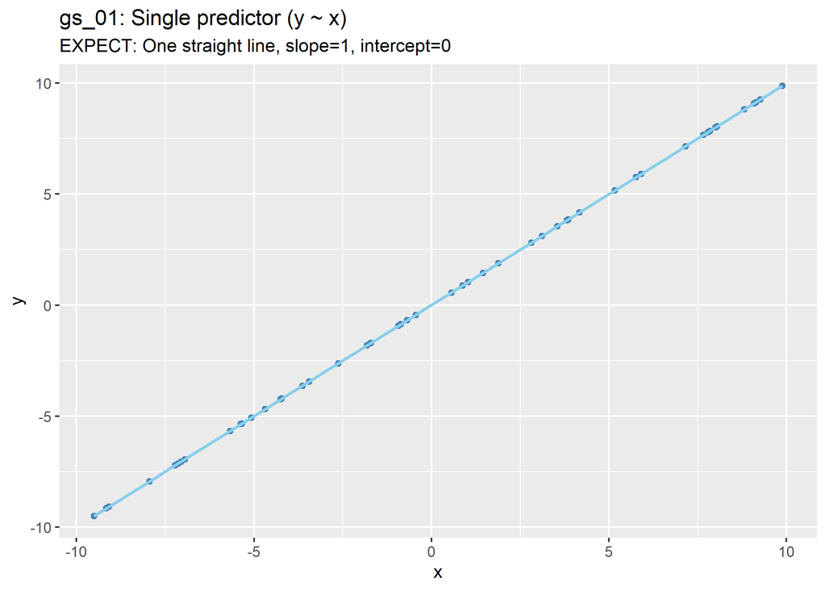

**Reference (ground truth):**

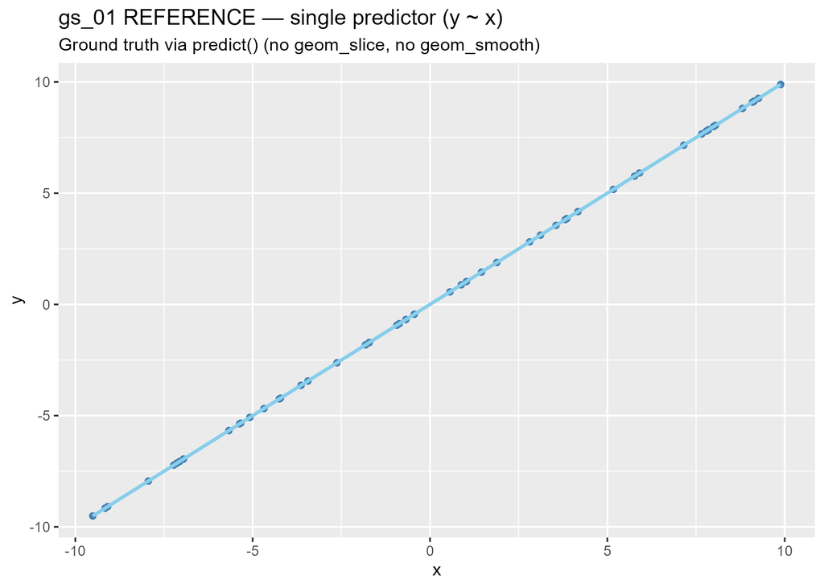

### gs_02_additive_default_held

> **Expect:** Scatter of x vs y (additive model y ~ x + x_pos). One fitted line, with x_pos auto-imputed to its mean (~5). Line should sit near the center of the point cloud. No errors.

**Status:** OK

```r
# CASE: gs_02_additive_default_held
# TYPE: visual
# FUNC: geom_slice
# EXPECT: Scatter of x vs y (additive model y ~ x + x_pos).
#         One fitted line, with x_pos auto-imputed to its mean (~5).
#         Line should sit near the center of the point cloud.
#         No errors.

source("tests/_setup.R")
set.seed(123)

n <- 50
x <- runif(n, -10, 10)
x_pos <- runif(n, 0, 10)
y <- x + x_pos + rnorm(n)
model <- lm(y ~ x + x_pos)

p <- ggplot(data.frame(x, y), aes(x, y)) +
  geom_point(color = "steelblue") +
  geom_slice(model) +
  labs(title = "gs_02: Additive model, default held value",
       subtitle = "EXPECT: One line at x_pos = mean(x_pos) ~= 5")
p
```

**Output (this run):**

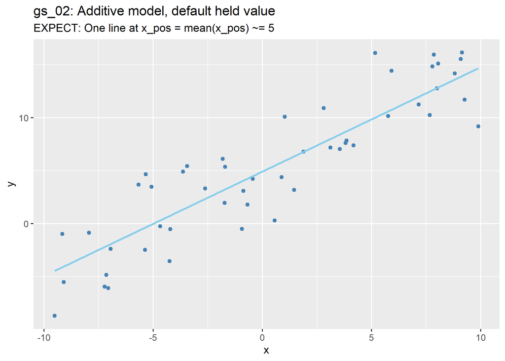

**Console output (this run):**

```
Value for `x_pos` not specified - Used mean: 4.77
    To choose a slice, use 'predict_vars = list(x_pos = 4.77)'.
```

**Reference (ground truth):**

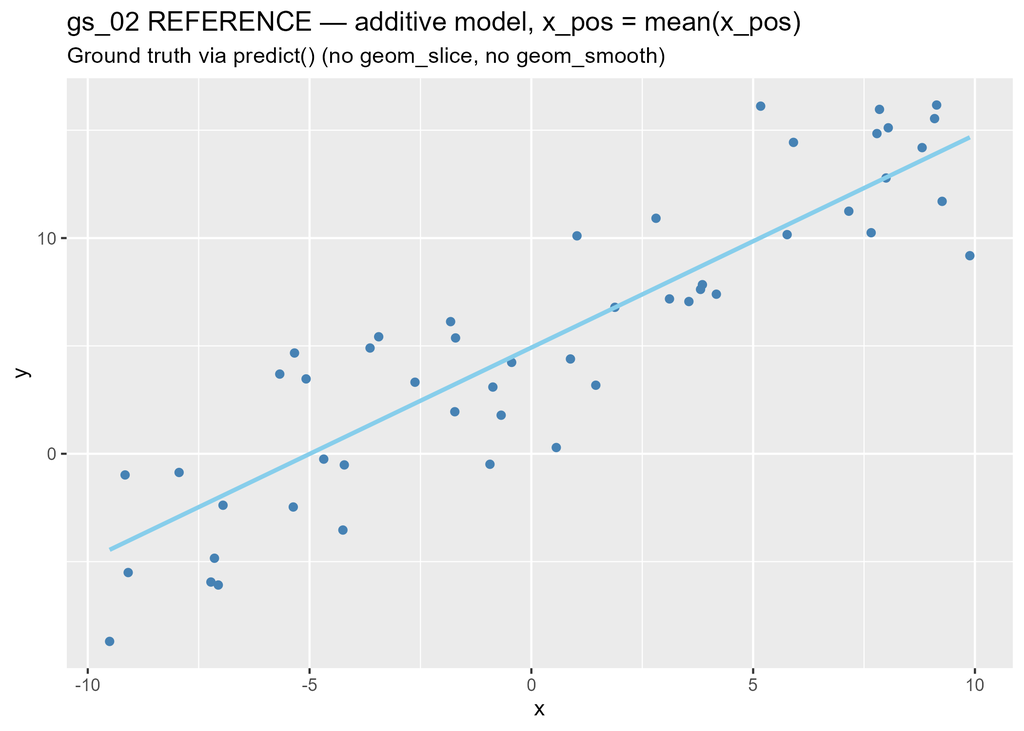

### gs_03_additive_predict_vars

> **Expect:** Same scatter as gs_02 (y ~ x + x_pos), but line uses x_pos = 0.007 (near the bottom of x_pos range). Line should be lower than in gs_02 because x_pos=0.007 contributes much less to y than mean(x_pos)~=5. No errors.

**Status:** OK

```r
# CASE: gs_03_additive_predict_vars
# TYPE: visual
# FUNC: geom_slice
# EXPECT: Same scatter as gs_02 (y ~ x + x_pos), but line uses x_pos = 0.007
#         (near the bottom of x_pos range). Line should be lower than in gs_02
#         because x_pos=0.007 contributes much less to y than mean(x_pos)~=5.
#         No errors.

source("tests/_setup.R")
set.seed(123)

n <- 50
x <- runif(n, -10, 10)
x_pos <- runif(n, 0, 10)
y <- x + x_pos + rnorm(n)
model <- lm(y ~ x + x_pos)

p <- ggplot(data.frame(x, y), aes(x, y)) +
  geom_point(color = "steelblue") +
  geom_slice(model, predict_vars = list(x_pos = 0.007)) +
  labs(title = "gs_03: Additive model, predict_vars = list(x_pos = 0.007)",
       subtitle = "EXPECT: One line near the bottom of the point cloud (x_pos very low)")
p
```

**Output (this run):**

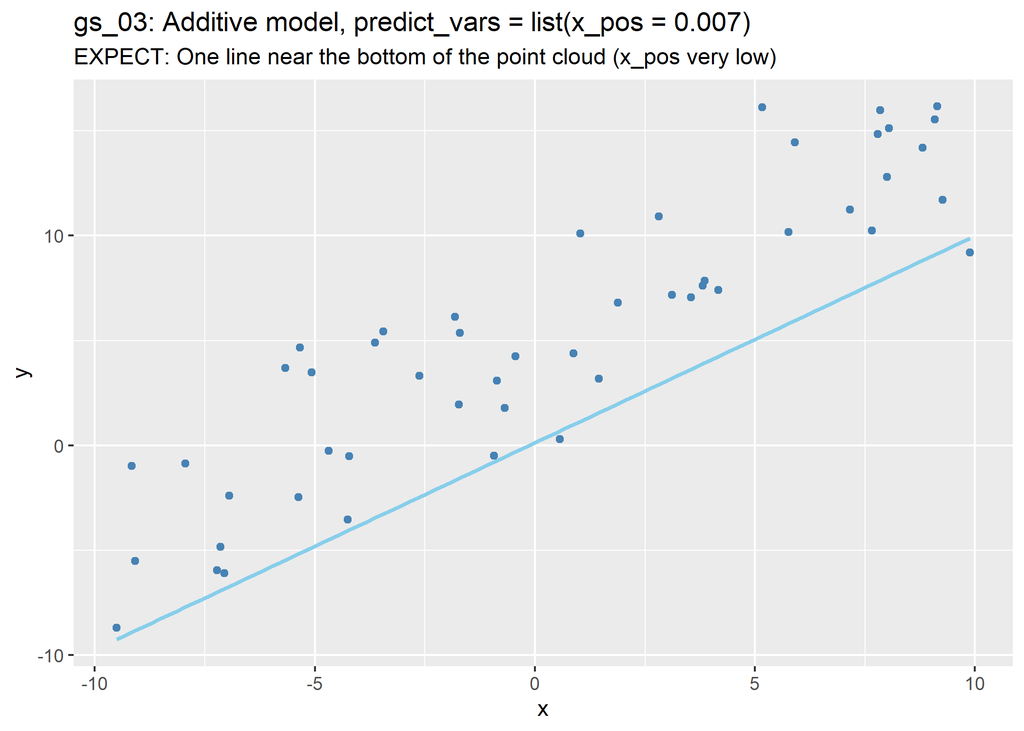

**Reference (ground truth):**

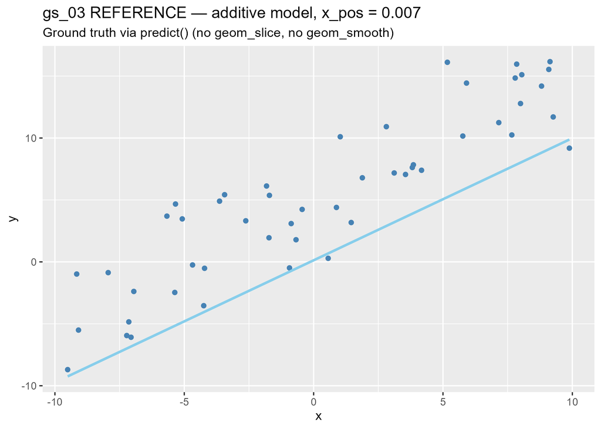

### gs_04_additive_two_slices

> **Expect:** Two parallel straight lines on the same scatter plot (y ~ x + x_pos). Blue line = x_pos held at 1 (lower line). Red line = x_pos held at 9 (upper line). The two lines should be clearly separated (intercept difference ~8), same slope, no crossing.

**Status:** OK

```r
# CASE: gs_04_additive_two_slices
# TYPE: visual
# FUNC: geom_slice
# EXPECT: Two parallel straight lines on the same scatter plot (y ~ x + x_pos).
#         Blue line = x_pos held at 1 (lower line).
#         Red line  = x_pos held at 9 (upper line).
#         The two lines should be clearly separated (intercept difference ~8),
#         same slope, no crossing.

source("tests/_setup.R")
set.seed(123)

n <- 50
x <- runif(n, -10, 10)
x_pos <- runif(n, 0, 10)
y <- x + x_pos + rnorm(n)
model <- lm(y ~ x + x_pos)

p <- ggplot(data.frame(x, y), aes(x, y)) +
  geom_point(color = "gray60") +
  geom_slice(model, predict_vars = list(x_pos = 1), color = "steelblue", linewidth = 1) +
  geom_slice(model, predict_vars = list(x_pos = 9), color = "firebrick", linewidth = 1) +
  labs(title = "gs_04: Two slices at x_pos=1 (blue) and x_pos=9 (red)",
       subtitle = "EXPECT: Two parallel lines, red higher than blue, same slope")
p
```

**Output (this run):**

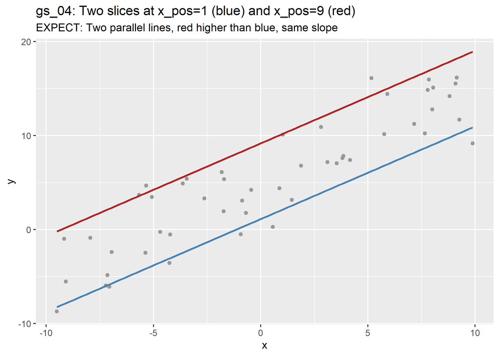

**Reference (ground truth):**

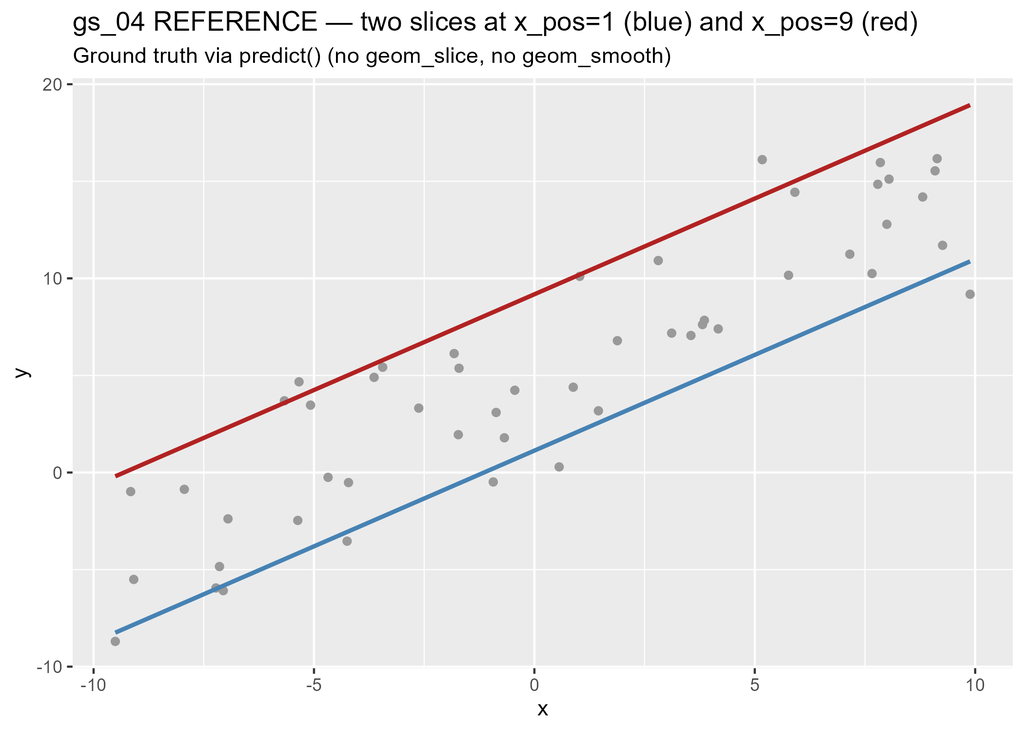

### gs_05_quadratic

> **Expect:** Scatter of x vs y (y ~ x + I(x^2)). One curved parabola-shaped line. The curve should open upward and pass through the point cloud. Not a straight line — must show visible curvature. No errors.

**Status:** OK

```r
# CASE: gs_05_quadratic
# TYPE: visual
# FUNC: geom_slice
# EXPECT: Scatter of x vs y (y ~ x + I(x^2)). One curved parabola-shaped line.
#         The curve should open upward and pass through the point cloud.
#         Not a straight line — must show visible curvature.
#         No errors.

source("tests/_setup.R")
set.seed(123)

n <- 50
x <- runif(n, -10, 10)
y <- x + x^2 + rnorm(n, sd = 3)
model <- lm(y ~ x + I(x^2))

p <- ggplot(data.frame(x, y), aes(x, y)) +
  geom_point(color = "steelblue") +
  geom_slice(model) +
  labs(title = "gs_05: Quadratic model (y ~ x + I(x^2))",
       subtitle = "EXPECT: Upward-opening parabola through points")
p
```

**Output (this run):**

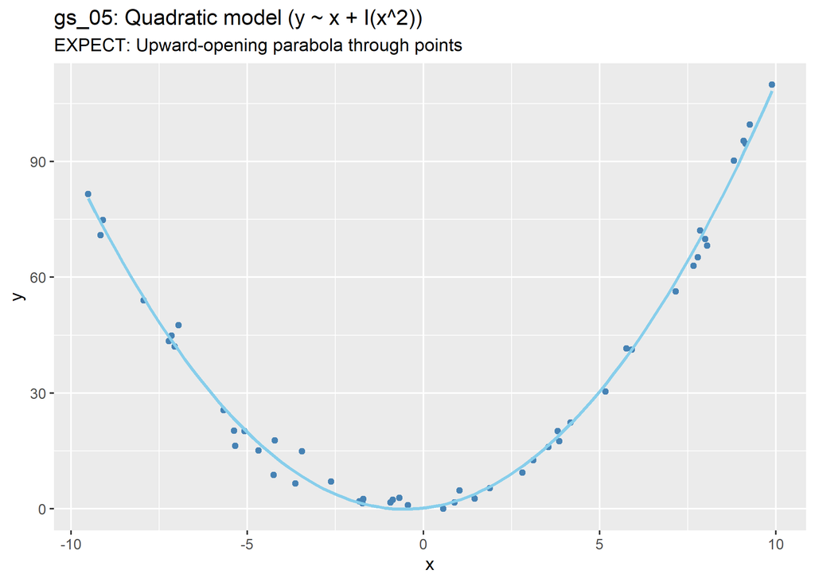

**Reference (ground truth):**

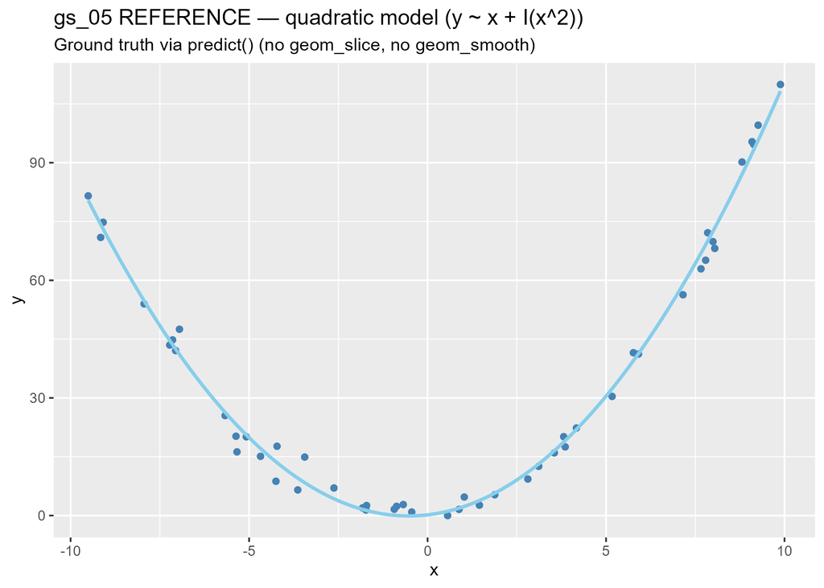

### gs_06_interaction_manual_slices

> **Expect:** Scatter of x vs y (y ~ x:x_switch) with three lines — one per x_switch level. x_switch=0 -> slope=0 (flat line at y=0) x_switch=1 -> slope~1 x_switch=2 -> slope~2 Three distinct lines with different slopes radiating from origin. No errors.

**Status:** OK

```r
# CASE: gs_06_interaction_manual_slices
# TYPE: visual
# FUNC: geom_slice
# EXPECT: Scatter of x vs y (y ~ x:x_switch) with three lines — one per x_switch level.
#         x_switch=0 -> slope=0 (flat line at y=0)
#         x_switch=1 -> slope~1
#         x_switch=2 -> slope~2
#         Three distinct lines with different slopes radiating from origin.
#         No errors.

source("tests/_setup.R")
set.seed(123)

n <- 50
x <- runif(n, -10, 10)
x_switch <- sample(c(0, 1, 2), n, replace = TRUE)
y <- x * x_switch + rnorm(n)
model <- lm(y ~ x:x_switch)

colors <- c("0" = "steelblue", "1" = "darkgreen", "2" = "purple")

p <- ggplot(data.frame(x, y, x_switch = factor(x_switch)), aes(x, y, color = x_switch)) +
  geom_point() +
  scale_color_manual(values = colors) +
  geom_slice(model, predict_vars = list(x_switch = 0), color = "steelblue", linewidth = 1) +
  geom_slice(model, predict_vars = list(x_switch = 1), color = "darkgreen", linewidth = 1) +
  geom_slice(model, predict_vars = list(x_switch = 2), color = "purple", linewidth = 1) +
  labs(title = "gs_06: Interaction model, three manual slices",
       subtitle = "EXPECT: Three lines with slopes 0, ~1, ~2 for x_switch = 0, 1, 2")
p
```

**Output (this run):**

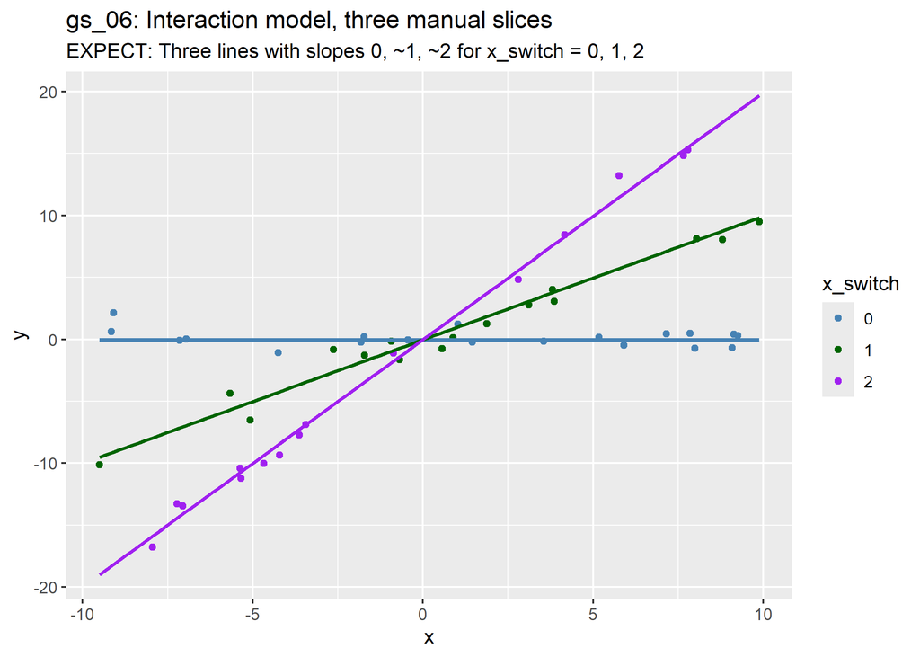

**Reference (ground truth):**

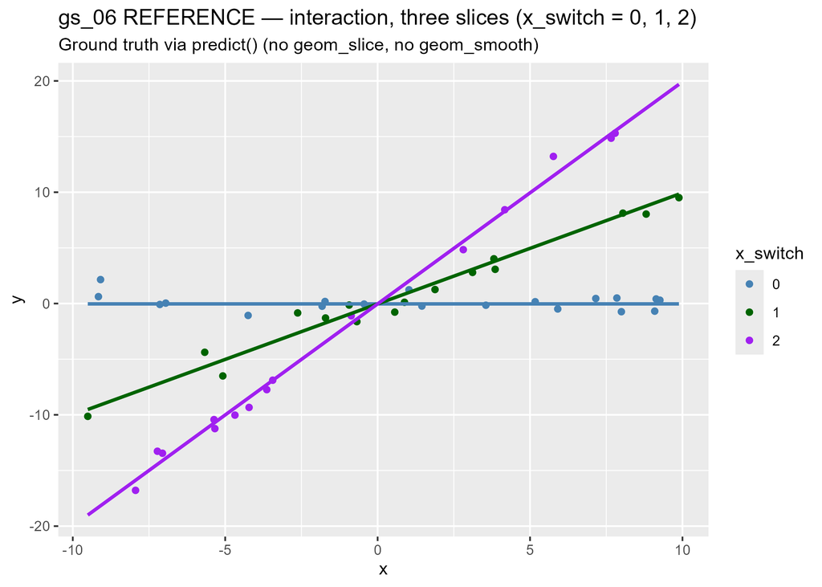

### gs_07_interaction_grouped

> **Expect:** Same interaction model as gs_06, but using a single geom_slice() call with color = factor(x_switch) in aes(). geom_slice should auto-detect groups and draw three colored lines (one per x_switch value). Result should visually match gs_06. No errors.

**Status:** OK

```r
# CASE: gs_07_interaction_grouped
# TYPE: visual
# FUNC: geom_slice
# EXPECT: Same interaction model as gs_06, but using a single geom_slice() call
#         with color = factor(x_switch) in aes(). geom_slice should auto-detect
#         groups and draw three colored lines (one per x_switch value).
#         Result should visually match gs_06.
#         No errors.

source("tests/_setup.R")
set.seed(123)

n <- 50
x <- runif(n, -10, 10)
x_switch <- sample(c(0, 1, 2), n, replace = TRUE)
y <- x * x_switch + rnorm(n)
model <- lm(y ~ x:x_switch)

p <- ggplot(data.frame(x, y, x_switch = factor(x_switch)),
            aes(x, y, color = factor(x_switch))) +
  geom_point() +
  geom_slice(model) +
  labs(title = "gs_07: Interaction model, auto-grouped via color aesthetic",
       subtitle = "EXPECT: Three colored lines auto-drawn from single geom_slice() call")
p
```

**Output (this run):**

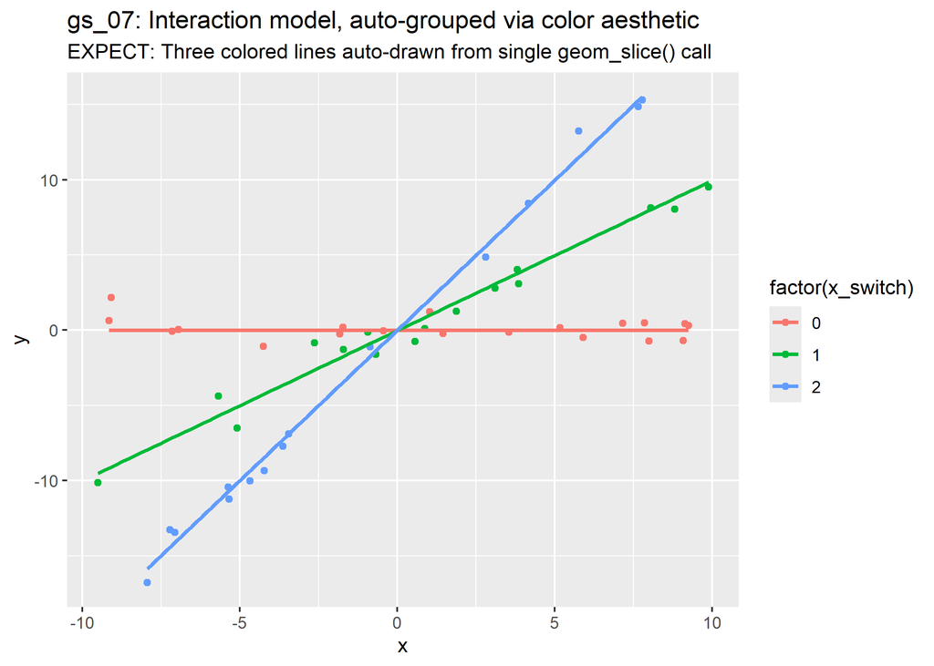

**Reference (ground truth):**

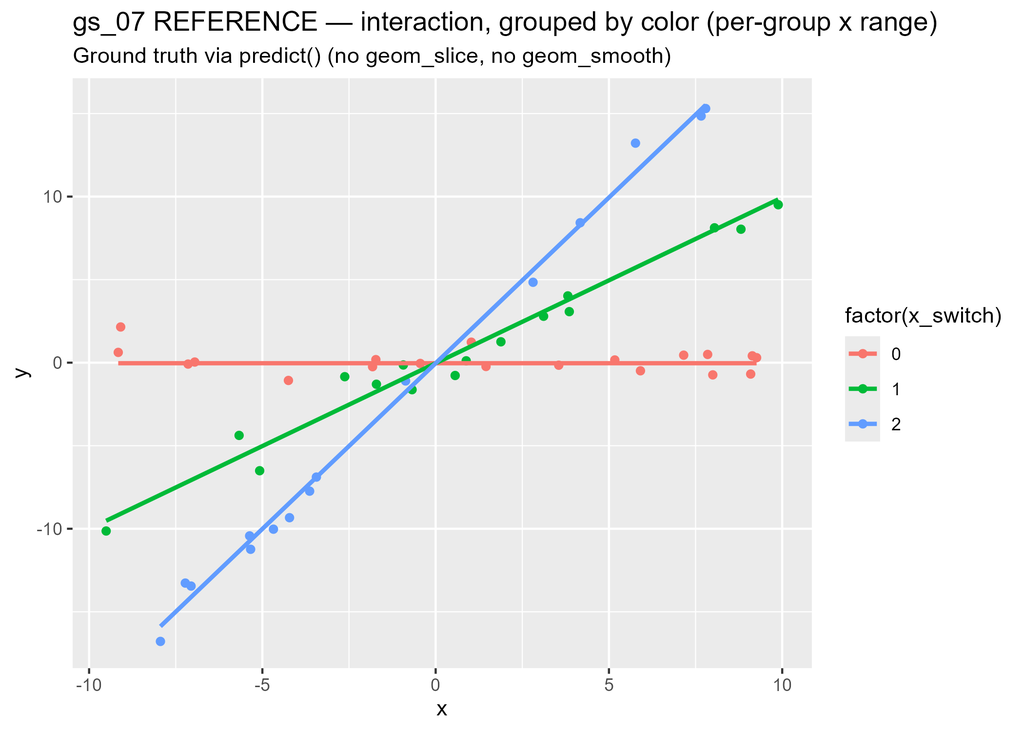

### gs_08_interaction_faceted

> **Expect:** Three facet panels (x_switch = 0, 1, 2), each showing the scatter for that group plus a fitted line appropriate to that x_switch value. Panel 0: flat line (slope~0). Panel 1: slope~1. Panel 2: slope~2. geom_slice() should detect the facet variable and slice accordingly. No errors.

**Status:** OK

```r
# CASE: gs_08_interaction_faceted
# TYPE: visual
# FUNC: geom_slice
# SIZE: 10x4
# EXPECT: Three facet panels (x_switch = 0, 1, 2), each showing the scatter
#         for that group plus a fitted line appropriate to that x_switch value.
#         Panel 0: flat line (slope~0). Panel 1: slope~1. Panel 2: slope~2.
#         geom_slice() should detect the facet variable and slice accordingly.
#         No errors.

source("tests/_setup.R")
set.seed(123)

n <- 50
x <- runif(n, -10, 10)
x_switch <- sample(c(0, 1, 2), n, replace = TRUE)
y <- x * x_switch + rnorm(n)
model <- lm(y ~ x:x_switch)

p <- ggplot(data.frame(x, y, x_switch), aes(x, y)) +
  geom_point(color = "steelblue") +
  facet_wrap(~x_switch) +
  geom_slice(model) +
  labs(title = "gs_08: Interaction model with facet_wrap(~x_switch)",
       subtitle = "EXPECT: Three panels, each with a correctly-sliced fitted line")
p
```

**Output (this run):**

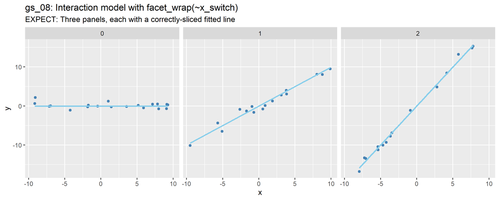

**Reference (ground truth):**

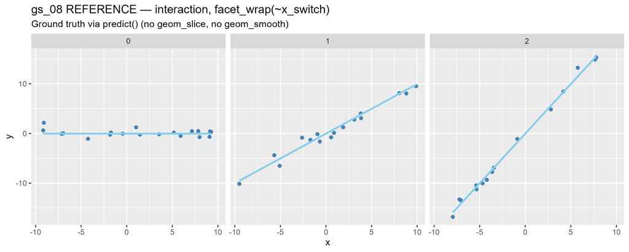

### gs_09_ytransform_log

> **Expect:** Scatter of x_pos vs y on the ORIGINAL (untransformed) y scale. Model is log(y) ~ x_pos, so y = exp(x_pos) approximately. geom_slice should back-transform: the fitted line must be exponential-shaped (curves upward), NOT a straight line. If the line is straight, back-transformation failed. Console message: predictions of log(y) back-transformed to the y axis.

**Status:** OK

```r
# CASE: gs_09_ytransform_log
# TYPE: visual
# FUNC: geom_slice
# EXPECT: Scatter of x_pos vs y on the ORIGINAL (untransformed) y scale.
#         Model is log(y) ~ x_pos, so y = exp(x_pos) approximately.
#         geom_slice should back-transform: the fitted line must be exponential-shaped
#         (curves upward), NOT a straight line.
#         If the line is straight, back-transformation failed.
#         Console message: predictions of log(y) back-transformed to the
#         y axis.

source("tests/_setup.R")
set.seed(123)

n <- 50
x_pos <- runif(n, 0, 10)
y <- exp(x_pos) * exp(rnorm(n, sd = 0.2))  # y = exp(x_pos + noise)
model <- lm(log(y) ~ x_pos)

p <- ggplot(data.frame(x_pos, y), aes(x_pos, y)) +
  geom_point(color = "steelblue") +
  geom_slice(model) +
  labs(title = "gs_09: Y-transform log(y) ~ x_pos",
       subtitle = "EXPECT: Exponential curve (back-transformed). Straight line = FAIL.")
p
```

**Output (this run):**

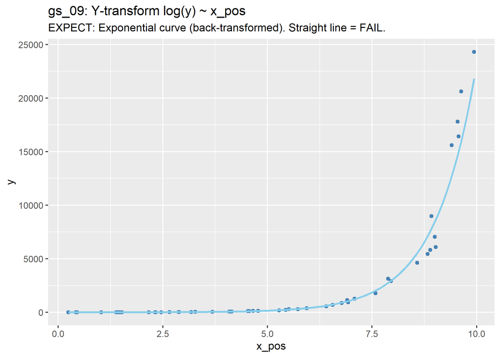

**Console output (this run):**

```
Predictions of `log(y)` were back-transformed to match the `y` axis.
    To turn this off, use 'back_transform = FALSE'.
```

**Reference (ground truth):**

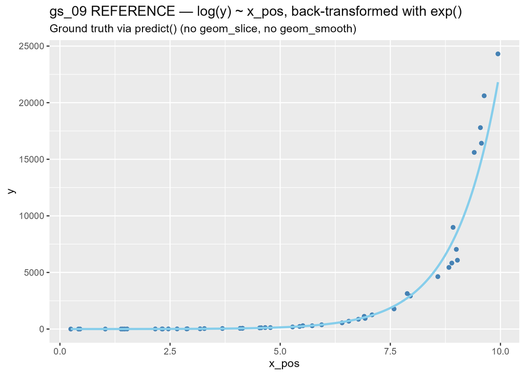

### gs_10_ytransform_sqrt

> **Expect:** Scatter of x_pos vs y on the ORIGINAL y scale (y = x_pos^2 approximately). Model is sqrt(y) ~ x_pos, so geom_slice must back-transform via squaring. The fitted line should be parabola-shaped (curves upward). A straight line on this plot means back-transformation failed. Console message: predictions of sqrt(y) back-transformed to the y axis.

**Status:** OK

```r
# CASE: gs_10_ytransform_sqrt
# TYPE: visual
# FUNC: geom_slice
# EXPECT: Scatter of x_pos vs y on the ORIGINAL y scale (y = x_pos^2 approximately).
#         Model is sqrt(y) ~ x_pos, so geom_slice must back-transform via squaring.
#         The fitted line should be parabola-shaped (curves upward).
#         A straight line on this plot means back-transformation failed.
#         Console message: predictions of sqrt(y) back-transformed to the
#         y axis.

source("tests/_setup.R")
set.seed(123)

n <- 50
x_pos <- runif(n, 0, 10)
y <- x_pos^2 + rnorm(n, sd = 2)
y <- pmax(y, 0)  # keep y non-negative for sqrt(y) to be valid
model <- lm(sqrt(y) ~ x_pos)

p <- ggplot(data.frame(x_pos, y), aes(x_pos, y)) +
  geom_point(color = "steelblue") +
  geom_slice(model) +
  labs(title = "gs_10: Y-transform sqrt(y) ~ x_pos",
       subtitle = "EXPECT: Parabola-shaped curve (back-transformed). Straight line = FAIL.")
p
```

**Output (this run):**

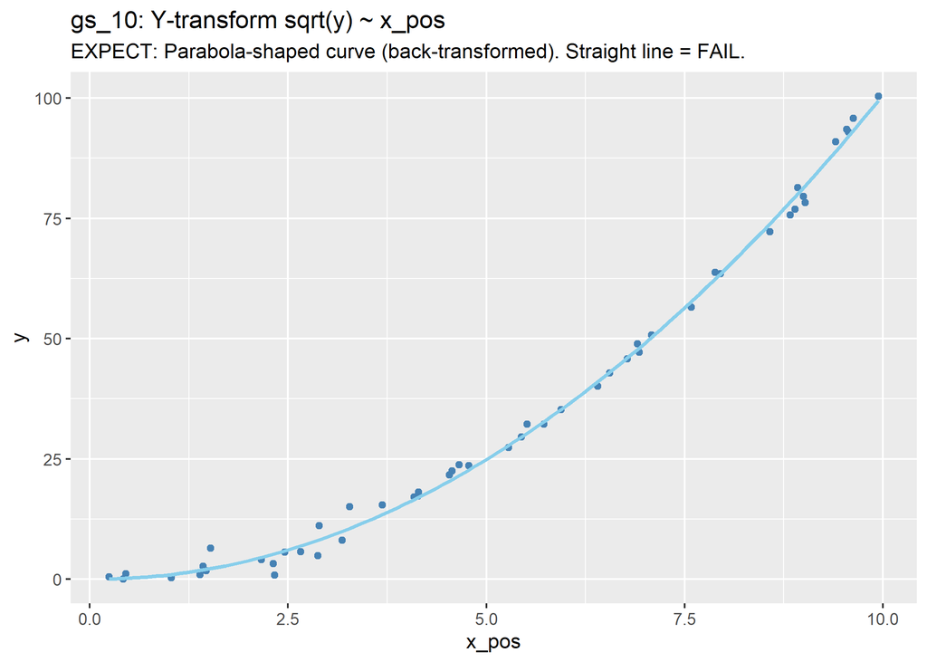

**Console output (this run):**

```
Predictions of `sqrt(y)` were back-transformed to match the `y` axis.
    To turn this off, use 'back_transform = FALSE'.
```

**Reference (ground truth):**

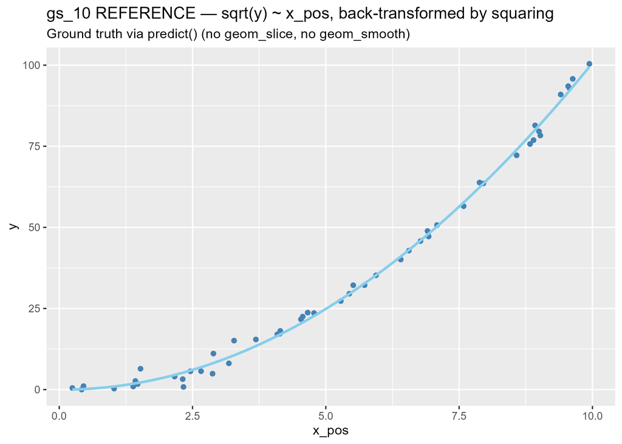

### gs_11_ytransform_inverse

> **Expect:** Scatter of x vs y on ORIGINAL y scale (y = 1/x, so hyperbolic shape). Model is 1/y ~ x, so geom_slice must back-transform via 1/fitted. The fitted line should be hyperbola-shaped: large y near x=0, approaching 0 as x grows large. A straight line on this plot means back-transformation failed. Console message: predictions of 1/y back-transformed to the y axis.

**Status:** OK

```r
# CASE: gs_11_ytransform_inverse
# TYPE: visual
# FUNC: geom_slice
# EXPECT: Scatter of x vs y on ORIGINAL y scale (y = 1/x, so hyperbolic shape).
#         Model is 1/y ~ x, so geom_slice must back-transform via 1/fitted.
#         The fitted line should be hyperbola-shaped: large y near x=0, approaching 0
#         as x grows large.
#         A straight line on this plot means back-transformation failed.
#         Console message: predictions of 1/y back-transformed to the y axis.

source("tests/_setup.R")
set.seed(123)

n <- 50
x <- runif(n, 1, 10)  # positive x only to avoid 1/0
y <- 1/x + rnorm(n, sd = 0.05)
model <- lm(1/y ~ x)

p <- ggplot(data.frame(x, y), aes(x, y)) +
  geom_point(color = "steelblue") +
  geom_slice(model) +
  labs(title = "gs_11: Y-transform 1/y ~ x",
       subtitle = "EXPECT: Hyperbolic curve, decreasing. Straight line = FAIL.")
p
```

**Output (this run):**

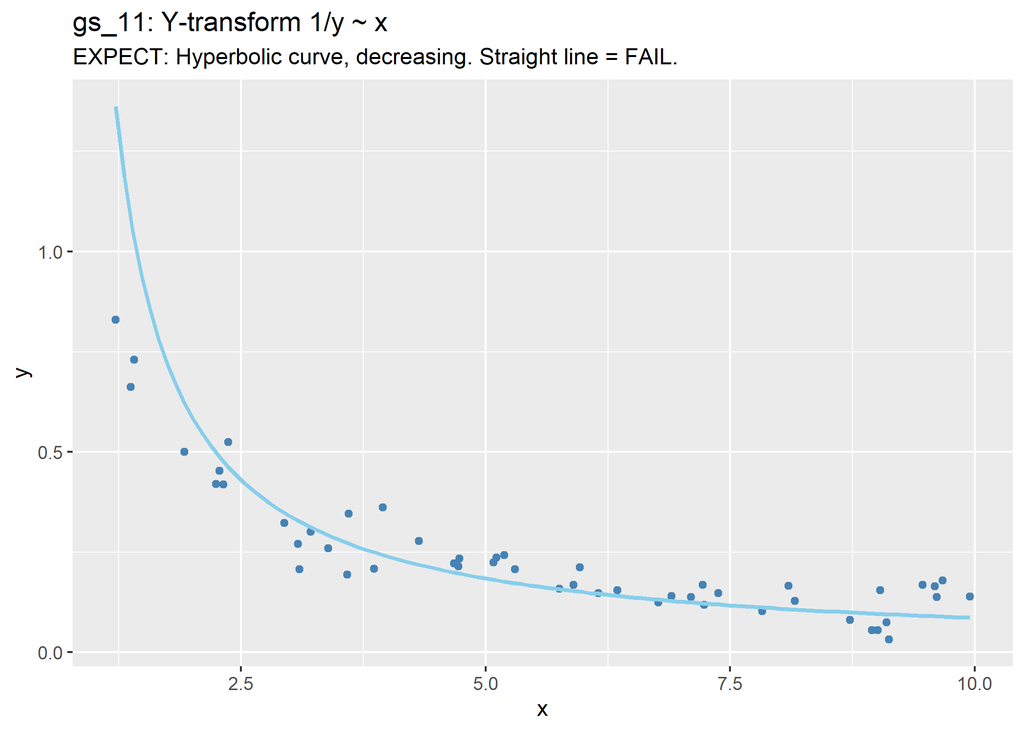

**Console output (this run):**

```
Predictions of `1/y` were back-transformed to match the `y` axis.
    To turn this off, use 'back_transform = FALSE'.
```

**Reference (ground truth):**

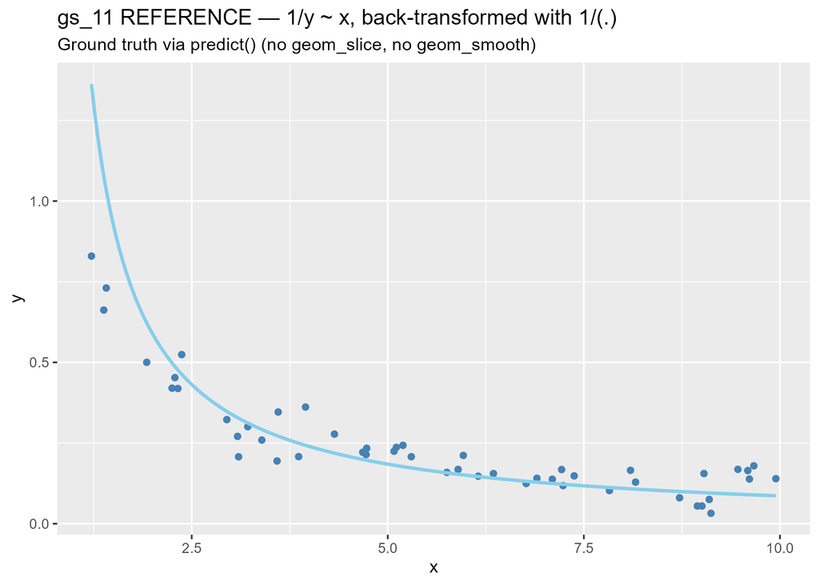

### gs_12_real_data_two_predictors

> **Expect:** mtcars scatter (disp vs mpg). Model is mpg ~ disp + hp. One fitted line with hp held at its mean (~146). Line should slope downward (more displacement -> less mpg) and pass through the middle of the point cloud. Console message: hp not specified, held at its mean (146.7). No errors.

**Status:** OK

```r
# CASE: gs_12_real_data_two_predictors
# TYPE: visual
# FUNC: geom_slice
# EXPECT: mtcars scatter (disp vs mpg). Model is mpg ~ disp + hp.
#         One fitted line with hp held at its mean (~146).
#         Line should slope downward (more displacement -> less mpg) and pass
#         through the middle of the point cloud.
#         Console message: hp not specified, held at its mean (146.7).
#         No errors.

source("tests/_setup.R")

model <- lm(mpg ~ disp + hp, data = mtcars)

p <- ggplot(mtcars, aes(disp, mpg)) +
  geom_point(color = "steelblue") +
  geom_slice(model) +
  labs(title = "gs_12: Real data — mpg ~ disp + hp, default held (hp = mean)",
       subtitle = "EXPECT: One downward-sloping line through the point cloud")
p
```

**Output (this run):**

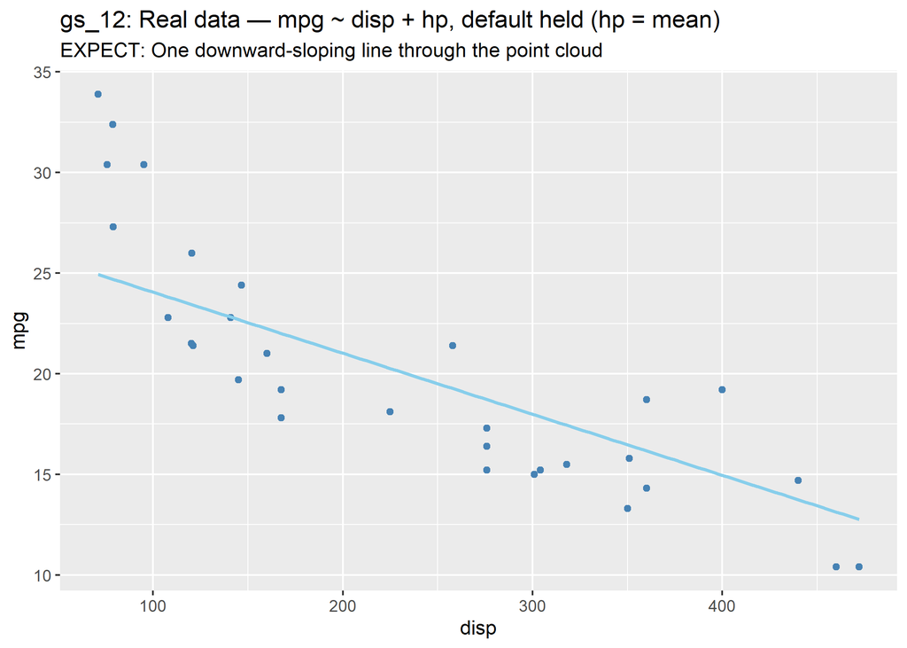

**Console output (this run):**

```
Value for `hp` not specified - Used mean: 146.7
    To choose a slice, use 'predict_vars = list(hp = 146.7)'.
```

**Reference (ground truth):**

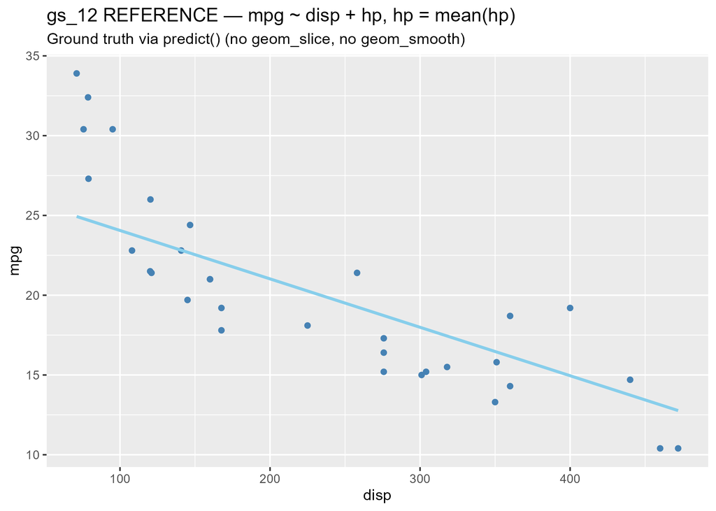

### gs_13_real_data_predict_vars

> **Expect:** mtcars scatter (disp vs mpg). Model is mpg ~ disp + hp. Two fitted lines: Blue line = hp held at 100 (low hp -> higher mpg prediction) Red line = hp held at 250 (high hp -> lower mpg prediction) Both lines slope downward. Red line sits below blue line. No errors.

**Status:** OK

```r
# CASE: gs_13_real_data_predict_vars
# TYPE: visual
# FUNC: geom_slice
# EXPECT: mtcars scatter (disp vs mpg). Model is mpg ~ disp + hp.
#         Two fitted lines:
#         Blue line = hp held at 100 (low hp -> higher mpg prediction)
#         Red line  = hp held at 250 (high hp -> lower mpg prediction)
#         Both lines slope downward. Red line sits below blue line.
#         No errors.

source("tests/_setup.R")

model <- lm(mpg ~ disp + hp, data = mtcars)

p <- ggplot(mtcars, aes(disp, mpg)) +
  geom_point(color = "gray60") +
  geom_slice(model, predict_vars = list(hp = 100), color = "steelblue", linewidth = 1) +
  geom_slice(model, predict_vars = list(hp = 250), color = "firebrick", linewidth = 1) +
  labs(title = "gs_13: Real data — two slices at hp=100 (blue) and hp=250 (red)",
       subtitle = "EXPECT: Blue line higher than red, both sloping down with disp")
p
```

**Output (this run):**

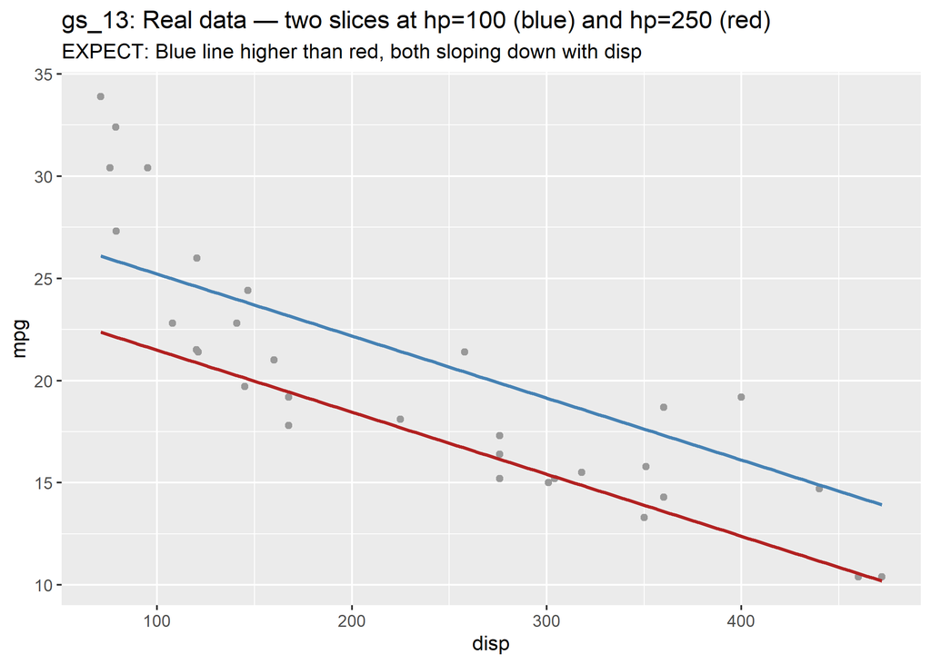

**Reference (ground truth):**

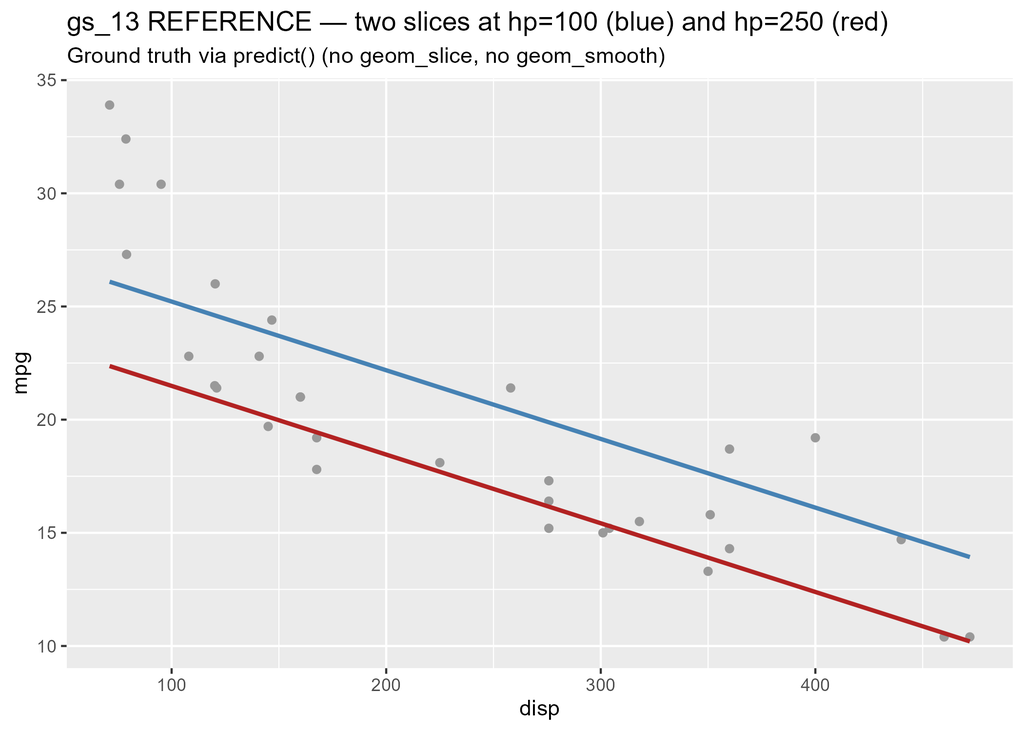

### gs_14_real_data_faceted

> **Expect:** Three facet panels for cyl = 4, 6, 8 (mtcars). Model is mpg ~ disp + hp + cyl. Each panel shows a steelblue downward-sloping line at hp=110. The lines must be positioned correctly for each cylinder level: cyl=4 panel at higher mpg, cyl=6 in the middle, cyl=8 at lower mpg. Lines should NOT be identical across panels (cyl matters). No errors.

**Status:** OK

```r
# CASE: gs_14_real_data_faceted
# TYPE: visual
# FUNC: geom_slice
# SIZE: 10x4
# EXPECT: Three facet panels for cyl = 4, 6, 8 (mtcars).
#         Model is mpg ~ disp + hp + cyl.
#         Each panel shows a steelblue downward-sloping line at hp=110.
#         The lines must be positioned correctly for each cylinder level:
#         cyl=4 panel at higher mpg, cyl=6 in the middle, cyl=8 at lower mpg.
#         Lines should NOT be identical across panels (cyl matters).
#         No errors.

source("tests/_setup.R")

model <- lm(mpg ~ disp + hp + cyl, data = mtcars)

p <- ggplot(mtcars, aes(disp, mpg)) +
  geom_point() +
  facet_wrap(~cyl) +
  geom_slice(model = model, predict_vars = list(hp = 110),
             color = "steelblue", linewidth = 1) +
  labs(title = "gs_14: Real data — mpg ~ disp + hp + cyl, facet_wrap(~cyl), hp=110",
       subtitle = "EXPECT: Three panels, each with correctly-positioned steelblue line")
p
```

**Output (this run):**

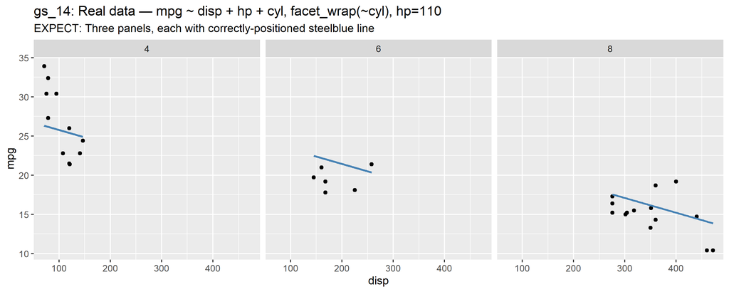

**Reference (ground truth):**

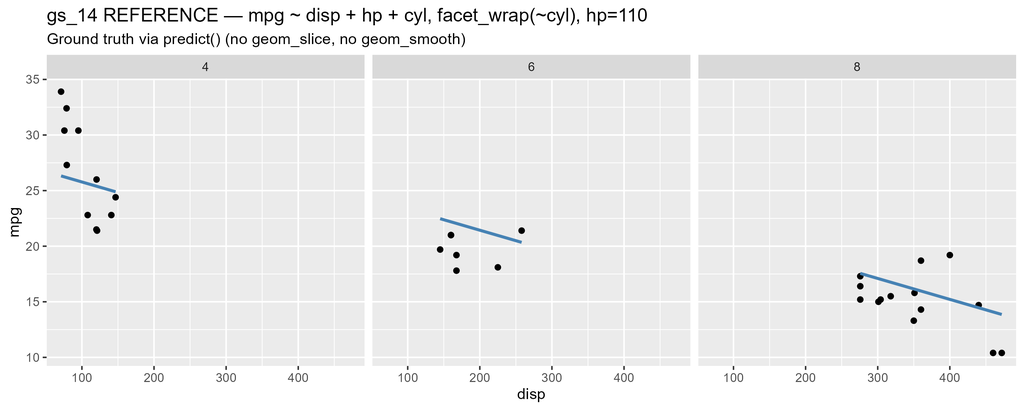

### gs_15_many_predictors

> **Expect:** mtcars scatter (disp vs mpg). Model has 4 predictors: disp + hp + wt + drat. predict_vars holds hp, wt, and drat at specific values. One nearly-flat (slightly rising) line: with hp/wt/drat held, disp’s partial coefficient is slightly positive (wt absorbs the downward trend). Tests that geom_slice can handle many held variables simultaneously. No errors.

**Status:** OK

```r
# CASE: gs_15_many_predictors
# TYPE: visual
# FUNC: geom_slice
# EXPECT: mtcars scatter (disp vs mpg). Model has 4 predictors: disp + hp + wt + drat.
#         predict_vars holds hp, wt, and drat at specific values.
#         One nearly-flat (slightly rising) line: with hp/wt/drat held, disp's
#         partial coefficient is slightly positive (wt absorbs the downward trend).
#         Tests that geom_slice can handle many held variables simultaneously.
#         No errors.

source("tests/_setup.R")

model <- lm(mpg ~ disp + hp + wt + drat, data = mtcars)

p <- ggplot(mtcars, aes(disp, mpg)) +
  geom_point(color = "steelblue") +
  geom_slice(model,
             predict_vars = list(hp = 110, wt = 3.0, drat = 3.5),
             color = "darkorange", linewidth = 1.2) +
  labs(title = "gs_15: Many predictors — mpg ~ disp + hp + wt + drat",
       subtitle = "EXPECT: One line, hp=110, wt=3.0, drat=3.5 held. No errors.")
p
```

**Output (this run):**

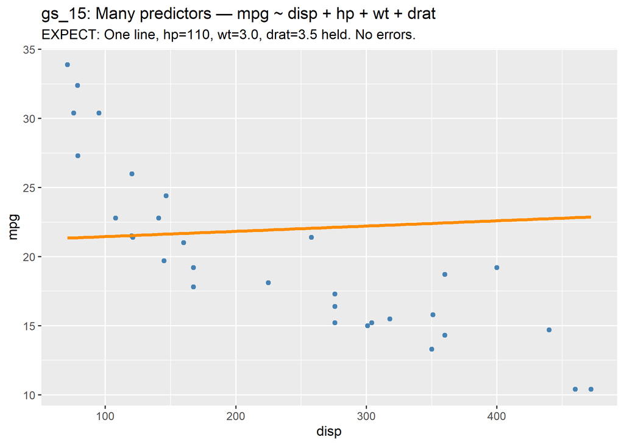

**Reference (ground truth):**

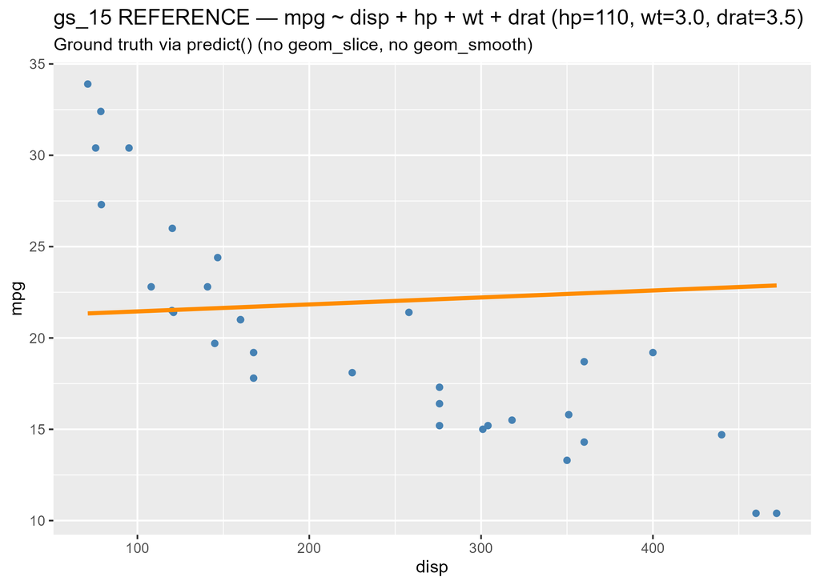

### gs_16_factor_predictor

> **Expect:** mtcars scatter (disp vs mpg), model mpg ~ factor(cyl) + disp. geom_slice called without predict_vars — cyl imputed to its most common level (“8”, 14 of 32 cars), reported by a console message. One line corresponding to the cyl=8 slice. Tests that geom_slice handles factor predictors without crashing. No errors. (If it crashes, factor handling in predict() is the likely culprit.)

**Status:** OK

```r
# CASE: gs_16_factor_predictor
# TYPE: visual
# FUNC: geom_slice
# EXPECT: mtcars scatter (disp vs mpg), model mpg ~ factor(cyl) + disp.
#         geom_slice called without predict_vars — cyl imputed to its most
#         common level ("8", 14 of 32 cars), reported by a console message.
#         One line corresponding to the cyl=8 slice.
#         Tests that geom_slice handles factor predictors without crashing.
#         No errors. (If it crashes, factor handling in predict() is the likely culprit.)

source("tests/_setup.R")

mtcars2 <- mtcars
mtcars2$cyl <- factor(mtcars2$cyl)
model <- lm(mpg ~ cyl + disp, data = mtcars2)

p <- ggplot(mtcars2, aes(disp, mpg)) +
  geom_point(color = "steelblue") +
  geom_slice(model) +
  labs(title = "gs_16: Factor predictor — mpg ~ factor(cyl) + disp",
       subtitle = "EXPECT: One line at imputed cyl level (mode, 8). No crash on factor variable.")
p
```

**Output (this run):**

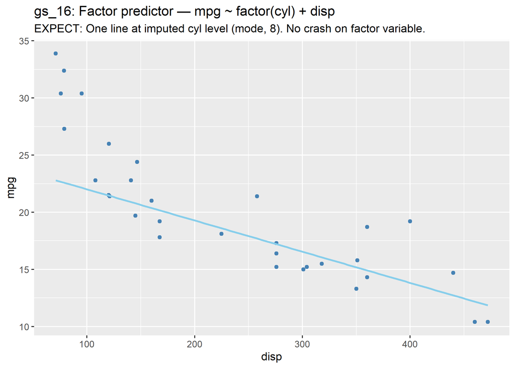

**Console output (this run):**

```
Value for `cyl` not specified - Used most common: "8"
    To choose a slice, use 'predict_vars = list(cyl = "8")'.
```

**Reference (ground truth):**

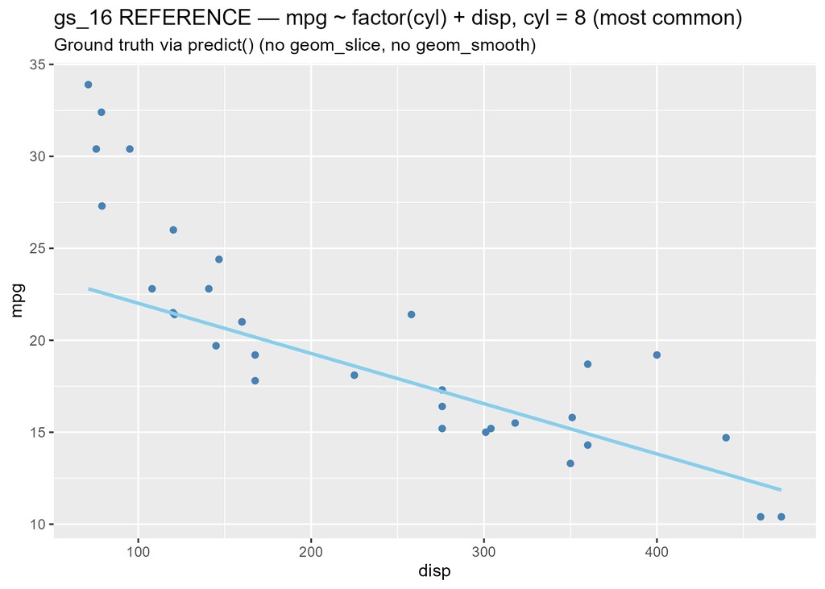